# Risk Factor Analysis

## Outcome Variable

**Outcome Variable:** ever_stunted

## Predictor Variables

**Intervention Variable:** enwast

**Adjustment Set:**

- arm
- sex
- W_mage
- meducyrs
- feducyrs
- hhwealth_quart
- vagbrth
- W_nrooms
- brthmon
- W_parity
- impsan
- delta_W_mage
- delta_meducyrs
- delta_feducyrs
- delta_hhwealth_quart
- delta_vagbrth
- delta_W_nrooms
- delta_brthmon
- delta_W_parity
- delta_impsan

## Stratifying Variables

The analysis was stratified on these variable(s):

- agecat
- studyid
- country

## Data Summary

| agecat | studyid | country | enwast | ever_stunted | n_cell | n |
| --- | --- | --- | --- | --- | --- | --- |
| 0-24 months (no birth st.) | ki0047075b-MAL-ED | BANGLADESH | 0 | 0 | 82 | 217 |
| 0-24 months (no birth st.) | ki0047075b-MAL-ED | BANGLADESH | 0 | 1 | 97 | 217 |
| 0-24 months (no birth st.) | ki0047075b-MAL-ED | BANGLADESH | 1 | 0 | 22 | 217 |
| 0-24 months (no birth st.) | ki0047075b-MAL-ED | BANGLADESH | 1 | 1 | 16 | 217 |
| 0-24 months (no birth st.) | ki0047075b-MAL-ED | BRAZIL | 0 | 0 | 172 | 207 |
| 0-24 months (no birth st.) | ki0047075b-MAL-ED | BRAZIL | 0 | 1 | 28 | 207 |
| 0-24 months (no birth st.) | ki0047075b-MAL-ED | BRAZIL | 1 | 0 | 6 | 207 |
| 0-24 months (no birth st.) | ki0047075b-MAL-ED | BRAZIL | 1 | 1 | 1 | 207 |
| 0-24 months (no birth st.) | ki0047075b-MAL-ED | INDIA | 0 | 0 | 78 | 209 |
| 0-24 months (no birth st.) | ki0047075b-MAL-ED | INDIA | 0 | 1 | 97 | 209 |
| 0-24 months (no birth st.) | ki0047075b-MAL-ED | INDIA | 1 | 0 | 23 | 209 |
| 0-24 months (no birth st.) | ki0047075b-MAL-ED | INDIA | 1 | 1 | 11 | 209 |
| 0-24 months (no birth st.) | ki0047075b-MAL-ED | NEPAL | 0 | 0 | 142 | 212 |
| 0-24 months (no birth st.) | ki0047075b-MAL-ED | NEPAL | 0 | 1 | 46 | 212 |
| 0-24 months (no birth st.) | ki0047075b-MAL-ED | NEPAL | 1 | 0 | 15 | 212 |
| 0-24 months (no birth st.) | ki0047075b-MAL-ED | NEPAL | 1 | 1 | 9 | 212 |
| 0-24 months (no birth st.) | ki0047075b-MAL-ED | PERU | 0 | 0 | 113 | 266 |
| 0-24 months (no birth st.) | ki0047075b-MAL-ED | PERU | 0 | 1 | 148 | 266 |
| 0-24 months (no birth st.) | ki0047075b-MAL-ED | PERU | 1 | 0 | 2 | 266 |
| 0-24 months (no birth st.) | ki0047075b-MAL-ED | PERU | 1 | 1 | 3 | 266 |
| 0-24 months (no birth st.) | ki0047075b-MAL-ED | SOUTH AFRICA | 0 | 0 | 129 | 280 |
| 0-24 months (no birth st.) | ki0047075b-MAL-ED | SOUTH AFRICA | 0 | 1 | 132 | 280 |
| 0-24 months (no birth st.) | ki0047075b-MAL-ED | SOUTH AFRICA | 1 | 0 | 14 | 280 |
| 0-24 months (no birth st.) | ki0047075b-MAL-ED | SOUTH AFRICA | 1 | 1 | 5 | 280 |
| 0-24 months (no birth st.) | ki0047075b-MAL-ED | TANZANIA, UNITED REPUBLIC OF | 0 | 0 | 41 | 219 |
| 0-24 months (no birth st.) | ki0047075b-MAL-ED | TANZANIA, UNITED REPUBLIC OF | 0 | 1 | 177 | 219 |
| 0-24 months (no birth st.) | ki0047075b-MAL-ED | TANZANIA, UNITED REPUBLIC OF | 1 | 0 | 0 | 219 |
| 0-24 months (no birth st.) | ki0047075b-MAL-ED | TANZANIA, UNITED REPUBLIC OF | 1 | 1 | 1 | 219 |
| 0-24 months (no birth st.) | ki1000108-CMC-V-BCS-2002 | INDIA | 0 | 0 | 22 | 296 |
| 0-24 months (no birth st.) | ki1000108-CMC-V-BCS-2002 | INDIA | 0 | 1 | 196 | 296 |

[output cut: 374 more lines]

The following strata were considered:

- agecat: 0-24 months (no birth st.), studyid: ki0047075b-MAL-ED, country: BANGLADESH
- agecat: 0-24 months (no birth st.), studyid: ki0047075b-MAL-ED, country: BRAZIL
- agecat: 0-24 months (no birth st.), studyid: ki0047075b-MAL-ED, country: INDIA
- agecat: 0-24 months (no birth st.), studyid: ki0047075b-MAL-ED, country: NEPAL
- agecat: 0-24 months (no birth st.), studyid: ki0047075b-MAL-ED, country: PERU
- agecat: 0-24 months (no birth st.), studyid: ki0047075b-MAL-ED, country: SOUTH AFRICA
- agecat: 0-24 months (no birth st.), studyid: ki0047075b-MAL-ED, country: TANZANIA, UNITED REPUBLIC OF
- agecat: 0-24 months (no birth st.), studyid: ki1000108-CMC-V-BCS-2002, country: INDIA
- agecat: 0-24 months (no birth st.), studyid: ki1000108-IRC, country: INDIA
- agecat: 0-24 months (no birth st.), studyid: ki1000109-EE, country: PAKISTAN
- agecat: 0-24 months (no birth st.), studyid: ki1000109-ResPak, country: PAKISTAN
- agecat: 0-24 months (no birth st.), studyid: ki1000304b-SAS-CompFeed, country: INDIA
- agecat: 0-24 months (no birth st.), studyid: ki1000304b-SAS-FoodSuppl, country: INDIA
- agecat: 0-24 months (no birth st.), studyid: ki1017093-NIH-Birth, country: BANGLADESH
- agecat: 0-24 months (no birth st.), studyid: ki1017093b-PROVIDE, country: BANGLADESH
- agecat: 0-24 months (no birth st.), studyid: ki1017093c-NIH-Crypto, country: BANGLADESH
- agecat: 0-24 months (no birth st.), studyid: ki1066203-TanzaniaChild2, country: TANZANIA, UNITED REPUBLIC OF
- agecat: 0-24 months (no birth st.), studyid: ki1101329-Keneba, country: GAMBIA
- agecat: 0-24 months (no birth st.), studyid: ki1112895-Guatemala BSC, country: GUATEMALA
- agecat: 0-24 months (no birth st.), studyid: ki1112895-iLiNS-Zinc, country: BURKINA FASO
- agecat: 0-24 months (no birth st.), studyid: ki1113344-GMS-Nepal, country: NEPAL
- agecat: 0-24 months (no birth st.), studyid: ki1114097-CMIN, country: BANGLADESH
- agecat: 0-24 months (no birth st.), studyid: ki1114097-CMIN, country: BRAZIL
- agecat: 0-24 months (no birth st.), studyid: ki1114097-CMIN, country: GUINEA-BISSAU
- agecat: 0-24 months (no birth st.), studyid: ki1114097-CMIN, country: PERU
- agecat: 0-24 months (no birth st.), studyid: ki1114097-CONTENT, country: PERU
- agecat: 0-24 months (no birth st.), studyid: ki1119695-PROBIT, country: BELARUS
- agecat: 0-24 months (no birth st.), studyid: ki1126311-ZVITAMBO, country: ZIMBABWE
- agecat: 0-24 months (no birth st.), studyid: ki1135781-COHORTS, country: GUATEMALA
- agecat: 0-24 months (no birth st.), studyid: ki1135781-COHORTS, country: INDIA
- agecat: 0-24 months (no birth st.), studyid: ki1135781-COHORTS, country: PHILIPPINES
- agecat: 0-24 months (no birth st.), studyid: ki1148112-LCNI-5, country: MALAWI
- agecat: 0-24 months (no birth st.), studyid: kiGH5241-JiVitA-3, country: BANGLADESH
- agecat: 0-24 months (no birth st.), studyid: kiGH5241-JiVitA-4, country: BANGLADESH
- agecat: 0-6 months (no birth st.), studyid: ki0047075b-MAL-ED, country: BANGLADESH
- agecat: 0-6 months (no birth st.), studyid: ki0047075b-MAL-ED, country: BRAZIL
- agecat: 0-6 months (no birth st.), studyid: ki0047075b-MAL-ED, country: INDIA
- agecat: 0-6 months (no birth st.), studyid: ki0047075b-MAL-ED, country: NEPAL
- agecat: 0-6 months (no birth st.), studyid: ki0047075b-MAL-ED, country: PERU
- agecat: 0-6 months (no birth st.), studyid: ki0047075b-MAL-ED, country: SOUTH AFRICA
- agecat: 0-6 months (no birth st.), studyid: ki0047075b-MAL-ED, country: TANZANIA, UNITED REPUBLIC OF
- agecat: 0-6 months (no birth st.), studyid: ki1000108-CMC-V-BCS-2002, country: INDIA
- agecat: 0-6 months (no birth st.), studyid: ki1000108-IRC, country: INDIA
- agecat: 0-6 months (no birth st.), studyid: ki1000109-EE, country: PAKISTAN
- agecat: 0-6 months (no birth st.), studyid: ki1000109-ResPak, country: PAKISTAN
- agecat: 0-6 months (no birth st.), studyid: ki1000304b-SAS-CompFeed, country: INDIA
- agecat: 0-6 months (no birth st.), studyid: ki1000304b-SAS-FoodSuppl, country: INDIA
- agecat: 0-6 months (no birth st.), studyid: ki1017093-NIH-Birth, country: BANGLADESH
- agecat: 0-6 months (no birth st.), studyid: ki1017093b-PROVIDE, country: BANGLADESH
- agecat: 0-6 months (no birth st.), studyid: ki1017093c-NIH-Crypto, country: BANGLADESH
- agecat: 0-6 months (no birth st.), studyid: ki1066203-TanzaniaChild2, country: TANZANIA, UNITED REPUBLIC OF
- agecat: 0-6 months (no birth st.), studyid: ki1101329-Keneba, country: GAMBIA
- agecat: 0-6 months (no birth st.), studyid: ki1112895-Guatemala BSC, country: GUATEMALA
- agecat: 0-6 months (no birth st.), studyid: ki1113344-GMS-Nepal, country: NEPAL
- agecat: 0-6 months (no birth st.), studyid: ki1114097-CMIN, country: BANGLADESH
- agecat: 0-6 months (no birth st.), studyid: ki1114097-CMIN, country: BRAZIL
- agecat: 0-6 months (no birth st.), studyid: ki1114097-CMIN, country: GUINEA-BISSAU
- agecat: 0-6 months (no birth st.), studyid: ki1114097-CMIN, country: PERU
- agecat: 0-6 months (no birth st.), studyid: ki1114097-CONTENT, country: PERU
- agecat: 0-6 months (no birth st.), studyid: ki1119695-PROBIT, country: BELARUS
- agecat: 0-6 months (no birth st.), studyid: ki1126311-ZVITAMBO, country: ZIMBABWE
- agecat: 0-6 months (no birth st.), studyid: ki1135781-COHORTS, country: GUATEMALA
- agecat: 0-6 months (no birth st.), studyid: ki1135781-COHORTS, country: INDIA
- agecat: 0-6 months (no birth st.), studyid: ki1135781-COHORTS, country: PHILIPPINES
- agecat: 0-6 months (no birth st.), studyid: ki1148112-LCNI-5, country: MALAWI
- agecat: 0-6 months (no birth st.), studyid: kiGH5241-JiVitA-3, country: BANGLADESH
- agecat: 0-6 months (no birth st.), studyid: kiGH5241-JiVitA-4, country: BANGLADESH
- agecat: 6-24 months, studyid: ki0047075b-MAL-ED, country: BANGLADESH
- agecat: 6-24 months, studyid: ki0047075b-MAL-ED, country: BRAZIL
- agecat: 6-24 months, studyid: ki0047075b-MAL-ED, country: INDIA
- agecat: 6-24 months, studyid: ki0047075b-MAL-ED, country: NEPAL
- agecat: 6-24 months, studyid: ki0047075b-MAL-ED, country: PERU
- agecat: 6-24 months, studyid: ki0047075b-MAL-ED, country: SOUTH AFRICA
- agecat: 6-24 months, studyid: ki0047075b-MAL-ED, country: TANZANIA, UNITED REPUBLIC OF
- agecat: 6-24 months, studyid: ki1000108-CMC-V-BCS-2002, country: INDIA
- agecat: 6-24 months, studyid: ki1000108-IRC, country: INDIA
- agecat: 6-24 months, studyid: ki1000109-EE, country: PAKISTAN
- agecat: 6-24 months, studyid: ki1000109-ResPak, country: PAKISTAN
- agecat: 6-24 months, studyid: ki1000304b-SAS-CompFeed, country: INDIA
- agecat: 6-24 months, studyid: ki1000304b-SAS-FoodSuppl, country: INDIA
- agecat: 6-24 months, studyid: ki1017093-NIH-Birth, country: BANGLADESH
- agecat: 6-24 months, studyid: ki1017093b-PROVIDE, country: BANGLADESH
- agecat: 6-24 months, studyid: ki1017093c-NIH-Crypto, country: BANGLADESH
- agecat: 6-24 months, studyid: ki1066203-TanzaniaChild2, country: TANZANIA, UNITED REPUBLIC OF
- agecat: 6-24 months, studyid: ki1101329-Keneba, country: GAMBIA
- agecat: 6-24 months, studyid: ki1112895-Guatemala BSC, country: GUATEMALA
- agecat: 6-24 months, studyid: ki1112895-iLiNS-Zinc, country: BURKINA FASO
- agecat: 6-24 months, studyid: ki1113344-GMS-Nepal, country: NEPAL
- agecat: 6-24 months, studyid: ki1114097-CMIN, country: BANGLADESH
- agecat: 6-24 months, studyid: ki1114097-CMIN, country: BRAZIL
- agecat: 6-24 months, studyid: ki1114097-CMIN, country: GUINEA-BISSAU
- agecat: 6-24 months, studyid: ki1114097-CMIN, country: PERU
- agecat: 6-24 months, studyid: ki1114097-CONTENT, country: PERU
- agecat: 6-24 months, studyid: ki1119695-PROBIT, country: BELARUS
- agecat: 6-24 months, studyid: ki1126311-ZVITAMBO, country: ZIMBABWE
- agecat: 6-24 months, studyid: ki1135781-COHORTS, country: GUATEMALA
- agecat: 6-24 months, studyid: ki1135781-COHORTS, country: INDIA
- agecat: 6-24 months, studyid: ki1135781-COHORTS, country: PHILIPPINES
- agecat: 6-24 months, studyid: ki1148112-LCNI-5, country: MALAWI
- agecat: 6-24 months, studyid: kiGH5241-JiVitA-3, country: BANGLADESH
- agecat: 6-24 months, studyid: kiGH5241-JiVitA-4, country: BANGLADESH

### Dropped Strata

Some strata were dropped due to rare outcomes:

- agecat: 0-24 months (no birth st.), studyid: ki0047075b-MAL-ED, country: BRAZIL
- agecat: 0-24 months (no birth st.), studyid: ki0047075b-MAL-ED, country: PERU
- agecat: 0-24 months (no birth st.), studyid: ki0047075b-MAL-ED, country: TANZANIA, UNITED REPUBLIC OF
- agecat: 0-24 months (no birth st.), studyid: ki1000109-EE, country: PAKISTAN
- agecat: 0-24 months (no birth st.), studyid: ki1112895-Guatemala BSC, country: GUATEMALA
- agecat: 0-24 months (no birth st.), studyid: ki1114097-CMIN, country: BRAZIL
- agecat: 0-24 months (no birth st.), studyid: ki1114097-CONTENT, country: PERU
- agecat: 0-24 months (no birth st.), studyid: ki1148112-LCNI-5, country: MALAWI
- agecat: 0-6 months (no birth st.), studyid: ki0047075b-MAL-ED, country: BRAZIL
- agecat: 0-6 months (no birth st.), studyid: ki0047075b-MAL-ED, country: NEPAL
- agecat: 0-6 months (no birth st.), studyid: ki0047075b-MAL-ED, country: PERU
- agecat: 0-6 months (no birth st.), studyid: ki0047075b-MAL-ED, country: SOUTH AFRICA
- agecat: 0-6 months (no birth st.), studyid: ki0047075b-MAL-ED, country: TANZANIA, UNITED REPUBLIC OF
- agecat: 0-6 months (no birth st.), studyid: ki1000304b-SAS-FoodSuppl, country: INDIA
- agecat: 0-6 months (no birth st.), studyid: ki1112895-Guatemala BSC, country: GUATEMALA
- agecat: 0-6 months (no birth st.), studyid: ki1114097-CMIN, country: BRAZIL
- agecat: 0-6 months (no birth st.), studyid: ki1114097-CMIN, country: GUINEA-BISSAU
- agecat: 0-6 months (no birth st.), studyid: ki1114097-CONTENT, country: PERU
- agecat: 0-6 months (no birth st.), studyid: ki1148112-LCNI-5, country: MALAWI
- agecat: 6-24 months, studyid: ki0047075b-MAL-ED, country: BRAZIL
- agecat: 6-24 months, studyid: ki0047075b-MAL-ED, country: PERU
- agecat: 6-24 months, studyid: ki0047075b-MAL-ED, country: SOUTH AFRICA
- agecat: 6-24 months, studyid: ki0047075b-MAL-ED, country: TANZANIA, UNITED REPUBLIC OF
- agecat: 6-24 months, studyid: ki1000109-EE, country: PAKISTAN
- agecat: 6-24 months, studyid: ki1000109-ResPak, country: PAKISTAN
- agecat: 6-24 months, studyid: ki1112895-Guatemala BSC, country: GUATEMALA
- agecat: 6-24 months, studyid: ki1114097-CMIN, country: BANGLADESH
- agecat: 6-24 months, studyid: ki1114097-CMIN, country: BRAZIL
- agecat: 6-24 months, studyid: ki1114097-CONTENT, country: PERU
- agecat: 6-24 months, studyid: ki1148112-LCNI-5, country: MALAWI

## Methods Detail

We’re interested in the causal parameters $E[Y_a]$ for all values of $a \in \mathcal{A}$. These parameters represent the mean outcome if, possibly contrary to fact, we intervened to set all units to have $A=a$. Under the randomization and positivity assumptions, these are identified by the statistical parameters $\psi_a=E_W[E_{Y|A,W}(Y|A=a,W)]$. In addition, we’re interested in the mean of $Y$, $E[Y]$ under no intervention (the observed mean). We will estimate these parameters by using SuperLearner to fit the relevant likelihood factors – $E_{Y|A,W}(Y|A=a,W)$ and $p(A=a|W)$, and then updating our likelihood fit using a joint TMLE.

For unadjusted analyses ($W=\{\}$), initial likelihoods were estimated using Lrnr_glm to estimate the simple $E(Y|A)$ and Lrnr_mean to estimate $p(A)$. For adjusted analyses, a small library containing Lrnr_glmnet, Lrnr_xgboost, and Lrnr_mean was used.

Having estimated these parameters, we will then use the delta method to estimate relative risks and attributable risks relative to a prespecified baseline level of $A$.

# Results Detail

## Results Plots

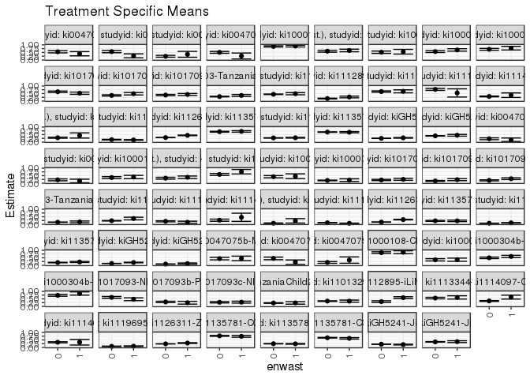

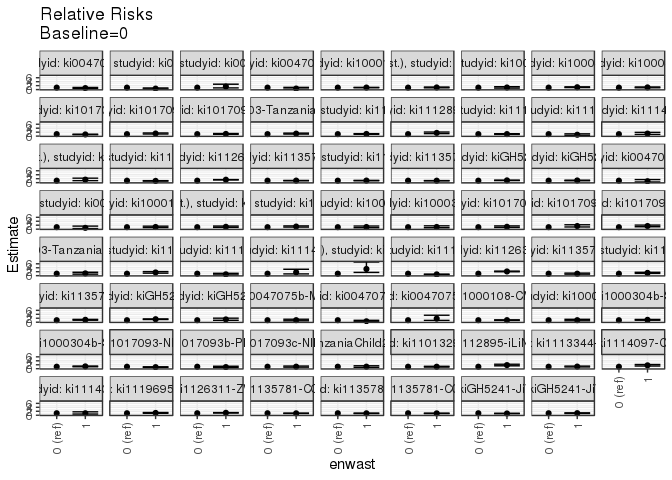

[figure not shown]

[figure not shown]

## Results Table

### Parameter: TSM

| agecat | studyid | country | intervention_level | baseline_level | estimate | ci_lower | ci_upper |
| --- | --- | --- | --- | --- | --- | --- | --- |
| 0-24 months (no birth st.) | ki0047075b-MAL-ED | BANGLADESH | 0 | NA | 0.5440553 | 0.4714361 | 0.6166745 |
| 0-24 months (no birth st.) | ki0047075b-MAL-ED | BANGLADESH | 1 | NA | 0.4136597 | 0.2733645 | 0.5539549 |
| 0-24 months (no birth st.) | ki0047075b-MAL-ED | INDIA | 0 | NA | 0.5534894 | 0.4799008 | 0.6270781 |
| 0-24 months (no birth st.) | ki0047075b-MAL-ED | INDIA | 1 | NA | 0.2761776 | 0.1465774 | 0.4057778 |
| 0-24 months (no birth st.) | ki0047075b-MAL-ED | NEPAL | 0 | NA | 0.2446809 | 0.1830836 | 0.3062781 |
| 0-24 months (no birth st.) | ki0047075b-MAL-ED | NEPAL | 1 | NA | 0.3750000 | 0.1808556 | 0.5691444 |
| 0-24 months (no birth st.) | ki0047075b-MAL-ED | SOUTH AFRICA | 0 | NA | 0.5057471 | 0.4449832 | 0.5665111 |
| 0-24 months (no birth st.) | ki0047075b-MAL-ED | SOUTH AFRICA | 1 | NA | 0.2631579 | 0.0648027 | 0.4615131 |
| 0-24 months (no birth st.) | ki1000108-CMC-V-BCS-2002 | INDIA | 0 | NA | 0.8990826 | 0.8590293 | 0.9391358 |
| 0-24 months (no birth st.) | ki1000108-CMC-V-BCS-2002 | INDIA | 1 | NA | 0.9230769 | 0.8638413 | 0.9823125 |
| 0-24 months (no birth st.) | ki1000108-IRC | INDIA | 0 | NA | 0.5819133 | 0.5184807 | 0.6453458 |
| 0-24 months (no birth st.) | ki1000108-IRC | INDIA | 1 | NA | 0.6307514 | 0.5464556 | 0.7150473 |
| 0-24 months (no birth st.) | ki1000109-ResPak | PAKISTAN | 0 | NA | 0.5143737 | 0.4374706 | 0.5912769 |
| 0-24 months (no birth st.) | ki1000109-ResPak | PAKISTAN | 1 | NA | 0.5467121 | 0.3920901 | 0.7013342 |
| 0-24 months (no birth st.) | ki1000304b-SAS-CompFeed | INDIA | 0 | NA | 0.5582522 | 0.4958103 | 0.6206941 |
| 0-24 months (no birth st.) | ki1000304b-SAS-CompFeed | INDIA | 1 | NA | 0.6665871 | 0.5861221 | 0.7470521 |
| 0-24 months (no birth st.) | ki1000304b-SAS-FoodSuppl | INDIA | 0 | NA | 0.7061611 | 0.6445783 | 0.7677440 |
| 0-24 months (no birth st.) | ki1000304b-SAS-FoodSuppl | INDIA | 1 | NA | 0.7826087 | 0.6631799 | 0.9020375 |
| 0-24 months (no birth st.) | ki1017093-NIH-Birth | BANGLADESH | 0 | NA | 0.6149865 | 0.5662519 | 0.6637212 |
| 0-24 months (no birth st.) | ki1017093-NIH-Birth | BANGLADESH | 1 | NA | 0.5201462 | 0.4452134 | 0.5950791 |
| 0-24 months (no birth st.) | ki1017093b-PROVIDE | BANGLADESH | 0 | NA | 0.3731022 | 0.3310328 | 0.4151715 |
| 0-24 months (no birth st.) | ki1017093b-PROVIDE | BANGLADESH | 1 | NA | 0.4853206 | 0.4037837 | 0.5668574 |
| 0-24 months (no birth st.) | ki1017093c-NIH-Crypto | BANGLADESH | 0 | NA | 0.3973554 | 0.3546491 | 0.4400617 |
| 0-24 months (no birth st.) | ki1017093c-NIH-Crypto | BANGLADESH | 1 | NA | 0.4367125 | 0.3711045 | 0.5023205 |
| 0-24 months (no birth st.) | ki1066203-TanzaniaChild2 | TANZANIA, UNITED REPUBLIC OF | 0 | NA | 0.2970464 | 0.2774914 | 0.3166015 |
| 0-24 months (no birth st.) | ki1066203-TanzaniaChild2 | TANZANIA, UNITED REPUBLIC OF | 1 | NA | 0.3720789 | 0.3066336 | 0.4375243 |
| 0-24 months (no birth st.) | ki1101329-Keneba | GAMBIA | 0 | NA | 0.4486684 | 0.4291130 | 0.4682239 |
| 0-24 months (no birth st.) | ki1101329-Keneba | GAMBIA | 1 | NA | 0.4861104 | 0.4150621 | 0.5571586 |
| 0-24 months (no birth st.) | ki1112895-iLiNS-Zinc | BURKINA FASO | 0 | NA | 0.1661243 | 0.1399154 | 0.1923332 |
| 0-24 months (no birth st.) | ki1112895-iLiNS-Zinc | BURKINA FASO | 1 | NA | 0.2691813 | 0.2125561 | 0.3258064 |

[output cut: 112 more lines]

### Parameter: E(Y)

| agecat | studyid | country | intervention_level | baseline_level | estimate | ci_lower | ci_upper |
| --- | --- | --- | --- | --- | --- | --- | --- |
| 0-24 months (no birth st.) | ki0047075b-MAL-ED | BANGLADESH | NA | NA | 0.5207373 | 0.4541154 | 0.5873593 |
| 0-24 months (no birth st.) | ki0047075b-MAL-ED | INDIA | NA | NA | 0.5167464 | 0.4488350 | 0.5846578 |
| 0-24 months (no birth st.) | ki0047075b-MAL-ED | NEPAL | NA | NA | 0.2594340 | 0.2002911 | 0.3185768 |
| 0-24 months (no birth st.) | ki0047075b-MAL-ED | SOUTH AFRICA | NA | NA | 0.4892857 | 0.4306292 | 0.5479422 |
| 0-24 months (no birth st.) | ki1000108-CMC-V-BCS-2002 | INDIA | NA | NA | 0.9054054 | 0.8720096 | 0.9388012 |
| 0-24 months (no birth st.) | ki1000108-IRC | INDIA | NA | NA | 0.5921788 | 0.5412016 | 0.6431559 |
| 0-24 months (no birth st.) | ki1000109-ResPak | PAKISTAN | NA | NA | 0.5198020 | 0.4507336 | 0.5888704 |
| 0-24 months (no birth st.) | ki1000304b-SAS-CompFeed | INDIA | NA | NA | 0.5660550 | 0.5086421 | 0.6234680 |
| 0-24 months (no birth st.) | ki1000304b-SAS-FoodSuppl | INDIA | NA | NA | 0.7198444 | 0.6648337 | 0.7748550 |
| 0-24 months (no birth st.) | ki1017093-NIH-Birth | BANGLADESH | NA | NA | 0.6018868 | 0.5601729 | 0.6436007 |
| 0-24 months (no birth st.) | ki1017093b-PROVIDE | BANGLADESH | NA | NA | 0.3753943 | 0.3376725 | 0.4131162 |
| 0-24 months (no birth st.) | ki1017093c-NIH-Crypto | BANGLADESH | NA | NA | 0.3935681 | 0.3560687 | 0.4310676 |
| 0-24 months (no birth st.) | ki1066203-TanzaniaChild2 | TANZANIA, UNITED REPUBLIC OF | NA | NA | 0.2984740 | 0.2794692 | 0.3174788 |
| 0-24 months (no birth st.) | ki1101329-Keneba | GAMBIA | NA | NA | 0.4523718 | 0.4332106 | 0.4715329 |
| 0-24 months (no birth st.) | ki1112895-iLiNS-Zinc | BURKINA FASO | NA | NA | 0.1780497 | 0.1518612 | 0.2042383 |
| 0-24 months (no birth st.) | ki1113344-GMS-Nepal | NEPAL | NA | NA | 0.6336449 | 0.5927799 | 0.6745099 |
| 0-24 months (no birth st.) | ki1114097-CMIN | BANGLADESH | NA | NA | 0.7559524 | 0.6908084 | 0.8210964 |
| 0-24 months (no birth st.) | ki1114097-CMIN | GUINEA-BISSAU | NA | NA | 0.3084337 | 0.2827691 | 0.3340984 |
| 0-24 months (no birth st.) | ki1114097-CMIN | PERU | NA | NA | 0.2976339 | 0.2659904 | 0.3292773 |
| 0-24 months (no birth st.) | ki1119695-PROBIT | BELARUS | NA | NA | 0.1597778 | 0.1408215 | 0.1787342 |
| 0-24 months (no birth st.) | ki1126311-ZVITAMBO | ZIMBABWE | NA | NA | 0.3258131 | 0.3176111 | 0.3340152 |
| 0-24 months (no birth st.) | ki1135781-COHORTS | GUATEMALA | NA | NA | 0.6972194 | 0.6683052 | 0.7261335 |
| 0-24 months (no birth st.) | ki1135781-COHORTS | INDIA | NA | NA | 0.2815773 | 0.2706357 | 0.2925189 |
| 0-24 months (no birth st.) | ki1135781-COHORTS | PHILIPPINES | NA | NA | 0.6647828 | 0.6473904 | 0.6821751 |
| 0-24 months (no birth st.) | kiGH5241-JiVitA-3 | BANGLADESH | NA | NA | 0.2537143 | 0.2459144 | 0.2615143 |
| 0-24 months (no birth st.) | kiGH5241-JiVitA-4 | BANGLADESH | NA | NA | 0.4170534 | 0.3987495 | 0.4353574 |
| 0-6 months (no birth st.) | ki0047075b-MAL-ED | BANGLADESH | NA | NA | 0.2119816 | 0.1574763 | 0.2664868 |
| 0-6 months (no birth st.) | ki0047075b-MAL-ED | INDIA | NA | NA | 0.2105263 | 0.1551227 | 0.2659300 |
| 0-6 months (no birth st.) | ki1000108-CMC-V-BCS-2002 | INDIA | NA | NA | 0.3835616 | 0.3276935 | 0.4394298 |
| 0-6 months (no birth st.) | ki1000108-IRC | INDIA | NA | NA | 0.3435754 | 0.2943128 | 0.3928380 |
| 0-6 months (no birth st.) | ki1000109-EE | PAKISTAN | NA | NA | 0.6024096 | 0.5415000 | 0.6633193 |
| 0-6 months (no birth st.) | ki1000109-ResPak | PAKISTAN | NA | NA | 0.4356436 | 0.3670959 | 0.5041912 |
| 0-6 months (no birth st.) | ki1000304b-SAS-CompFeed | INDIA | NA | NA | 0.1928375 | 0.1691727 | 0.2165022 |
| 0-6 months (no birth st.) | ki1017093-NIH-Birth | BANGLADESH | NA | NA | 0.2283019 | 0.1925336 | 0.2640702 |
| 0-6 months (no birth st.) | ki1017093b-PROVIDE | BANGLADESH | NA | NA | 0.1593060 | 0.1307970 | 0.1878149 |
| 0-6 months (no birth st.) | ki1017093c-NIH-Crypto | BANGLADESH | NA | NA | 0.1898928 | 0.1597870 | 0.2199986 |
| 0-6 months (no birth st.) | ki1066203-TanzaniaChild2 | TANZANIA, UNITED REPUBLIC OF | NA | NA | 0.1368941 | 0.1226179 | 0.1511703 |
| 0-6 months (no birth st.) | ki1101329-Keneba | GAMBIA | NA | NA | 0.2414875 | 0.2237281 | 0.2592468 |
| 0-6 months (no birth st.) | ki1113344-GMS-Nepal | NEPAL | NA | NA | 0.1869159 | 0.1538509 | 0.2199809 |
| 0-6 months (no birth st.) | ki1114097-CMIN | BANGLADESH | NA | NA | 0.2857143 | 0.2171983 | 0.3542303 |
| 0-6 months (no birth st.) | ki1114097-CMIN | PERU | NA | NA | 0.0744681 | 0.0543935 | 0.0945427 |
| 0-6 months (no birth st.) | ki1119695-PROBIT | BELARUS | NA | NA | 0.0912784 | 0.0781588 | 0.1043979 |
| 0-6 months (no birth st.) | ki1126311-ZVITAMBO | ZIMBABWE | NA | NA | 0.1711093 | 0.1645149 | 0.1777037 |
| 0-6 months (no birth st.) | ki1135781-COHORTS | GUATEMALA | NA | NA | 0.2195677 | 0.1921865 | 0.2469489 |
| 0-6 months (no birth st.) | ki1135781-COHORTS | INDIA | NA | NA | 0.0732095 | 0.0667753 | 0.0796436 |
| 0-6 months (no birth st.) | ki1135781-COHORTS | PHILIPPINES | NA | NA | 0.1889792 | 0.1745554 | 0.2034029 |
| 0-6 months (no birth st.) | kiGH5241-JiVitA-3 | BANGLADESH | NA | NA | 0.1311618 | 0.1255296 | 0.1367940 |
| 0-6 months (no birth st.) | kiGH5241-JiVitA-4 | BANGLADESH | NA | NA | 0.0855893 | 0.0742297 | 0.0969489 |
| 6-24 months | ki0047075b-MAL-ED | BANGLADESH | NA | NA | 0.4213836 | 0.3443902 | 0.4983771 |
| 6-24 months | ki0047075b-MAL-ED | INDIA | NA | NA | 0.4129032 | 0.3351414 | 0.4906651 |
| 6-24 months | ki0047075b-MAL-ED | NEPAL | NA | NA | 0.2102564 | 0.1529155 | 0.2675974 |
| 6-24 months | ki1000108-CMC-V-BCS-2002 | INDIA | NA | NA | 0.8478261 | 0.7957850 | 0.8998671 |
| 6-24 months | ki1000108-IRC | INDIA | NA | NA | 0.3787234 | 0.3165730 | 0.4408738 |
| 6-24 months | ki1000304b-SAS-CompFeed | INDIA | NA | NA | 0.5030750 | 0.4588491 | 0.5473009 |
| 6-24 months | ki1000304b-SAS-FoodSuppl | INDIA | NA | NA | 0.7572016 | 0.7031798 | 0.8112234 |
| 6-24 months | ki1017093-NIH-Birth | BANGLADESH | NA | NA | 0.5739130 | 0.5216565 | 0.6261696 |
| 6-24 months | ki1017093b-PROVIDE | BANGLADESH | NA | NA | 0.2997812 | 0.2577294 | 0.3418330 |
| 6-24 months | ki1017093c-NIH-Crypto | BANGLADESH | NA | NA | 0.2628458 | 0.2244546 | 0.3012371 |
| 6-24 months | ki1066203-TanzaniaChild2 | TANZANIA, UNITED REPUBLIC OF | NA | NA | 0.2255639 | 0.2050525 | 0.2460753 |
| 6-24 months | ki1101329-Keneba | GAMBIA | NA | NA | 0.3588089 | 0.3378609 | 0.3797570 |
| 6-24 months | ki1112895-iLiNS-Zinc | BURKINA FASO | NA | NA | 0.3623277 | 0.3130786 | 0.4115769 |
| 6-24 months | ki1113344-GMS-Nepal | NEPAL | NA | NA | 0.5610329 | 0.5138522 | 0.6082135 |
| 6-24 months | ki1114097-CMIN | GUINEA-BISSAU | NA | NA | 0.3710037 | 0.3451775 | 0.3968300 |
| 6-24 months | ki1114097-CMIN | PERU | NA | NA | 0.3450439 | 0.3120195 | 0.3780683 |
| 6-24 months | ki1119695-PROBIT | BELARUS | NA | NA | 0.0768510 | 0.0628857 | 0.0908164 |
| 6-24 months | ki1126311-ZVITAMBO | ZIMBABWE | NA | NA | 0.2459285 | 0.2364444 | 0.2554126 |
| 6-24 months | ki1135781-COHORTS | GUATEMALA | NA | NA | 0.7684332 | 0.7403543 | 0.7965121 |
| 6-24 months | ki1135781-COHORTS | INDIA | NA | NA | 0.2473250 | 0.2361242 | 0.2585258 |
| 6-24 months | ki1135781-COHORTS | PHILIPPINES | NA | NA | 0.6435738 | 0.6230503 | 0.6640973 |
| 6-24 months | kiGH5241-JiVitA-3 | BANGLADESH | NA | NA | 0.2165538 | 0.2071947 | 0.2259129 |
| 6-24 months | kiGH5241-JiVitA-4 | BANGLADESH | NA | NA | 0.3728692 | 0.3541664 | 0.3915720 |

### Parameter: RR

| agecat | studyid | country | intervention_level | baseline_level | estimate | ci_lower | ci_upper |
| --- | --- | --- | --- | --- | --- | --- | --- |
| 0-24 months (no birth st.) | ki0047075b-MAL-ED | BANGLADESH | 0 | 0 | 1.0000000 | 1.0000000 | 1.0000000 |
| 0-24 months (no birth st.) | ki0047075b-MAL-ED | BANGLADESH | 1 | 0 | 0.7603265 | 0.5289862 | 1.0928384 |
| 0-24 months (no birth st.) | ki0047075b-MAL-ED | INDIA | 0 | 0 | 1.0000000 | 1.0000000 | 1.0000000 |
| 0-24 months (no birth st.) | ki0047075b-MAL-ED | INDIA | 1 | 0 | 0.4989754 | 0.3065575 | 0.8121688 |
| 0-24 months (no birth st.) | ki0047075b-MAL-ED | NEPAL | 0 | 0 | 1.0000000 | 1.0000000 | 1.0000000 |
| 0-24 months (no birth st.) | ki0047075b-MAL-ED | NEPAL | 1 | 0 | 1.5326087 | 0.8618198 | 2.7254994 |
| 0-24 months (no birth st.) | ki0047075b-MAL-ED | SOUTH AFRICA | 0 | 0 | 1.0000000 | 1.0000000 | 1.0000000 |
| 0-24 months (no birth st.) | ki0047075b-MAL-ED | SOUTH AFRICA | 1 | 0 | 0.5203349 | 0.2425499 | 1.1162589 |
| 0-24 months (no birth st.) | ki1000108-CMC-V-BCS-2002 | INDIA | 0 | 0 | 1.0000000 | 1.0000000 | 1.0000000 |
| 0-24 months (no birth st.) | ki1000108-CMC-V-BCS-2002 | INDIA | 1 | 0 | 1.0266876 | 0.9495361 | 1.1101078 |
| 0-24 months (no birth st.) | ki1000108-IRC | INDIA | 0 | 0 | 1.0000000 | 1.0000000 | 1.0000000 |
| 0-24 months (no birth st.) | ki1000108-IRC | INDIA | 1 | 0 | 1.0839269 | 0.9127501 | 1.2872061 |
| 0-24 months (no birth st.) | ki1000109-ResPak | PAKISTAN | 0 | 0 | 1.0000000 | 1.0000000 | 1.0000000 |
| 0-24 months (no birth st.) | ki1000109-ResPak | PAKISTAN | 1 | 0 | 1.0628694 | 0.7723203 | 1.4627239 |
| 0-24 months (no birth st.) | ki1000304b-SAS-CompFeed | INDIA | 0 | 0 | 1.0000000 | 1.0000000 | 1.0000000 |
| 0-24 months (no birth st.) | ki1000304b-SAS-CompFeed | INDIA | 1 | 0 | 1.1940609 | 1.0349641 | 1.3776143 |
| 0-24 months (no birth st.) | ki1000304b-SAS-FoodSuppl | INDIA | 0 | 0 | 1.0000000 | 1.0000000 | 1.0000000 |
| 0-24 months (no birth st.) | ki1000304b-SAS-FoodSuppl | INDIA | 1 | 0 | 1.1082580 | 0.9296242 | 1.3212174 |
| 0-24 months (no birth st.) | ki1017093-NIH-Birth | BANGLADESH | 0 | 0 | 1.0000000 | 1.0000000 | 1.0000000 |
| 0-24 months (no birth st.) | ki1017093-NIH-Birth | BANGLADESH | 1 | 0 | 0.8457848 | 0.7176658 | 0.9967757 |
| 0-24 months (no birth st.) | ki1017093b-PROVIDE | BANGLADESH | 0 | 0 | 1.0000000 | 1.0000000 | 1.0000000 |
| 0-24 months (no birth st.) | ki1017093b-PROVIDE | BANGLADESH | 1 | 0 | 1.3007711 | 1.0628713 | 1.5919194 |
| 0-24 months (no birth st.) | ki1017093c-NIH-Crypto | BANGLADESH | 0 | 0 | 1.0000000 | 1.0000000 | 1.0000000 |
| 0-24 months (no birth st.) | ki1017093c-NIH-Crypto | BANGLADESH | 1 | 0 | 1.0990476 | 0.9149580 | 1.3201760 |
| 0-24 months (no birth st.) | ki1066203-TanzaniaChild2 | TANZANIA, UNITED REPUBLIC OF | 0 | 0 | 1.0000000 | 1.0000000 | 1.0000000 |
| 0-24 months (no birth st.) | ki1066203-TanzaniaChild2 | TANZANIA, UNITED REPUBLIC OF | 1 | 0 | 1.2525951 | 1.0381790 | 1.5112948 |
| 0-24 months (no birth st.) | ki1101329-Keneba | GAMBIA | 0 | 0 | 1.0000000 | 1.0000000 | 1.0000000 |
| 0-24 months (no birth st.) | ki1101329-Keneba | GAMBIA | 1 | 0 | 1.0834512 | 0.9308919 | 1.2610127 |
| 0-24 months (no birth st.) | ki1112895-iLiNS-Zinc | BURKINA FASO | 0 | 0 | 1.0000000 | 1.0000000 | 1.0000000 |
| 0-24 months (no birth st.) | ki1112895-iLiNS-Zinc | BURKINA FASO | 1 | 0 | 1.6203609 | 1.2675759 | 2.0713310 |

[output cut: 112 more lines]

### Parameter: PAR

| agecat | studyid | country | intervention_level | baseline_level | estimate | ci_lower | ci_upper |
| --- | --- | --- | --- | --- | --- | --- | --- |
| 0-24 months (no birth st.) | ki0047075b-MAL-ED | BANGLADESH | 0 | NA | -0.0233180 | -0.0538262 | 0.0071902 |
| 0-24 months (no birth st.) | ki0047075b-MAL-ED | INDIA | 0 | NA | -0.0367430 | -0.0672085 | -0.0062776 |
| 0-24 months (no birth st.) | ki0047075b-MAL-ED | NEPAL | 0 | NA | 0.0147531 | -0.0089687 | 0.0384750 |
| 0-24 months (no birth st.) | ki0047075b-MAL-ED | SOUTH AFRICA | 0 | NA | -0.0164614 | -0.0322545 | -0.0006684 |
| 0-24 months (no birth st.) | ki1000108-CMC-V-BCS-2002 | INDIA | 0 | NA | 0.0063228 | -0.0125586 | 0.0252042 |
| 0-24 months (no birth st.) | ki1000108-IRC | INDIA | 0 | NA | 0.0102655 | -0.0268044 | 0.0473355 |
| 0-24 months (no birth st.) | ki1000109-ResPak | PAKISTAN | 0 | NA | 0.0054282 | -0.0282633 | 0.0391198 |
| 0-24 months (no birth st.) | ki1000304b-SAS-CompFeed | INDIA | 0 | NA | 0.0078029 | -0.0056091 | 0.0212148 |
| 0-24 months (no birth st.) | ki1000304b-SAS-FoodSuppl | INDIA | 0 | NA | 0.0136832 | -0.0106341 | 0.0380006 |
| 0-24 months (no birth st.) | ki1017093-NIH-Birth | BANGLADESH | 0 | NA | -0.0130998 | -0.0402889 | 0.0140894 |
| 0-24 months (no birth st.) | ki1017093b-PROVIDE | BANGLADESH | 0 | NA | 0.0022921 | -0.0170234 | 0.0216077 |
| 0-24 months (no birth st.) | ki1017093c-NIH-Crypto | BANGLADESH | 0 | NA | -0.0037872 | -0.0253326 | 0.0177582 |
| 0-24 months (no birth st.) | ki1066203-TanzaniaChild2 | TANZANIA, UNITED REPUBLIC OF | 0 | NA | 0.0014275 | -0.0035181 | 0.0063731 |
| 0-24 months (no birth st.) | ki1101329-Keneba | GAMBIA | 0 | NA | 0.0037033 | -0.0003660 | 0.0077727 |
| 0-24 months (no birth st.) | ki1112895-iLiNS-Zinc | BURKINA FASO | 0 | NA | 0.0119255 | 0.0046511 | 0.0191998 |
| 0-24 months (no birth st.) | ki1113344-GMS-Nepal | NEPAL | 0 | NA | 0.0020904 | -0.0161538 | 0.0203346 |
| 0-24 months (no birth st.) | ki1114097-CMIN | BANGLADESH | 0 | NA | -0.0182412 | -0.0418995 | 0.0054172 |
| 0-24 months (no birth st.) | ki1114097-CMIN | GUINEA-BISSAU | 0 | NA | 0.0024643 | -0.0024070 | 0.0073355 |
| 0-24 months (no birth st.) | ki1114097-CMIN | PERU | 0 | NA | 0.0059025 | -0.0012732 | 0.0130783 |
| 0-24 months (no birth st.) | ki1119695-PROBIT | BELARUS | 0 | NA | -0.0038422 | -0.0080523 | 0.0003678 |
| 0-24 months (no birth st.) | ki1126311-ZVITAMBO | ZIMBABWE | 0 | NA | 0.0231258 | 0.0191537 | 0.0270979 |
| 0-24 months (no birth st.) | ki1135781-COHORTS | GUATEMALA | 0 | NA | 0.0070070 | -0.0067737 | 0.0207877 |
| 0-24 months (no birth st.) | ki1135781-COHORTS | INDIA | 0 | NA | 0.0027944 | -0.0022594 | 0.0078482 |
| 0-24 months (no birth st.) | ki1135781-COHORTS | PHILIPPINES | 0 | NA | -0.0020700 | -0.0096459 | 0.0055059 |
| 0-24 months (no birth st.) | kiGH5241-JiVitA-3 | BANGLADESH | 0 | NA | 0.0039451 | 0.0014454 | 0.0064448 |
| 0-24 months (no birth st.) | kiGH5241-JiVitA-4 | BANGLADESH | 0 | NA | 0.0016688 | -0.0036316 | 0.0069692 |
| 0-6 months (no birth st.) | ki0047075b-MAL-ED | BANGLADESH | 0 | NA | -0.0114821 | -0.0347172 | 0.0117529 |
| 0-6 months (no birth st.) | ki0047075b-MAL-ED | INDIA | 0 | NA | -0.0123308 | -0.0345210 | 0.0098594 |
| 0-6 months (no birth st.) | ki1000108-CMC-V-BCS-2002 | INDIA | 0 | NA | 0.0092801 | -0.0241405 | 0.0427007 |
| 0-6 months (no birth st.) | ki1000108-IRC | INDIA | 0 | NA | 0.0102240 | -0.0262523 | 0.0467003 |
| 0-6 months (no birth st.) | ki1000109-EE | PAKISTAN | 0 | NA | 0.0199293 | -0.0013024 | 0.0411610 |
| 0-6 months (no birth st.) | ki1000109-ResPak | PAKISTAN | 0 | NA | 0.0064322 | -0.0271804 | 0.0400447 |
| 0-6 months (no birth st.) | ki1000304b-SAS-CompFeed | INDIA | 0 | NA | 0.0094031 | -0.0029752 | 0.0217813 |
| 0-6 months (no birth st.) | ki1017093-NIH-Birth | BANGLADESH | 0 | NA | 0.0139963 | -0.0091108 | 0.0371035 |
| 0-6 months (no birth st.) | ki1017093b-PROVIDE | BANGLADESH | 0 | NA | 0.0111088 | -0.0043324 | 0.0265499 |
| 0-6 months (no birth st.) | ki1017093c-NIH-Crypto | BANGLADESH | 0 | NA | 0.0033225 | -0.0148263 | 0.0214713 |
| 0-6 months (no birth st.) | ki1066203-TanzaniaChild2 | TANZANIA, UNITED REPUBLIC OF | 0 | NA | 0.0012835 | -0.0025140 | 0.0050810 |
| 0-6 months (no birth st.) | ki1101329-Keneba | GAMBIA | 0 | NA | 0.0080228 | 0.0036463 | 0.0123994 |
| 0-6 months (no birth st.) | ki1113344-GMS-Nepal | NEPAL | 0 | NA | -0.0107980 | -0.0242780 | 0.0026820 |
| 0-6 months (no birth st.) | ki1114097-CMIN | BANGLADESH | 0 | NA | 0.0147465 | -0.0083076 | 0.0378007 |
| 0-6 months (no birth st.) | ki1114097-CMIN | PERU | 0 | NA | 0.0074824 | 0.0000240 | 0.0149409 |
| 0-6 months (no birth st.) | ki1119695-PROBIT | BELARUS | 0 | NA | -0.0066847 | -0.0108597 | -0.0025097 |
| 0-6 months (no birth st.) | ki1126311-ZVITAMBO | ZIMBABWE | 0 | NA | 0.0265003 | 0.0228492 | 0.0301515 |
| 0-6 months (no birth st.) | ki1135781-COHORTS | GUATEMALA | 0 | NA | -0.0078198 | -0.0223570 | 0.0067173 |
| 0-6 months (no birth st.) | ki1135781-COHORTS | INDIA | 0 | NA | 0.0060647 | 0.0026795 | 0.0094500 |
| 0-6 months (no birth st.) | ki1135781-COHORTS | PHILIPPINES | 0 | NA | 0.0028797 | -0.0034983 | 0.0092578 |
| 0-6 months (no birth st.) | kiGH5241-JiVitA-3 | BANGLADESH | 0 | NA | 0.0068161 | 0.0046855 | 0.0089466 |
| 0-6 months (no birth st.) | kiGH5241-JiVitA-4 | BANGLADESH | 0 | NA | 0.0027251 | -0.0008643 | 0.0063145 |
| 6-24 months | ki0047075b-MAL-ED | BANGLADESH | 0 | NA | -0.0267229 | -0.0626424 | 0.0091966 |
| 6-24 months | ki0047075b-MAL-ED | INDIA | 0 | NA | -0.0474142 | -0.0831398 | -0.0116887 |
| 6-24 months | ki0047075b-MAL-ED | NEPAL | 0 | NA | 0.0159707 | -0.0073222 | 0.0392635 |
| 6-24 months | ki1000108-CMC-V-BCS-2002 | INDIA | 0 | NA | 0.0072464 | -0.0216144 | 0.0361072 |
| 6-24 months | ki1000108-IRC | INDIA | 0 | NA | 0.0113975 | -0.0326198 | 0.0554149 |
| 6-24 months | ki1000304b-SAS-CompFeed | INDIA | 0 | NA | 0.0034575 | -0.0062403 | 0.0131554 |
| 6-24 months | ki1000304b-SAS-FoodSuppl | INDIA | 0 | NA | 0.0208832 | -0.0010346 | 0.0428011 |
| 6-24 months | ki1017093-NIH-Birth | BANGLADESH | 0 | NA | -0.0275971 | -0.0596891 | 0.0044949 |
| 6-24 months | ki1017093b-PROVIDE | BANGLADESH | 0 | NA | 0.0028380 | -0.0177486 | 0.0234247 |
| 6-24 months | ki1017093c-NIH-Crypto | BANGLADESH | 0 | NA | -0.0119439 | -0.0330270 | 0.0091392 |
| 6-24 months | ki1066203-TanzaniaChild2 | TANZANIA, UNITED REPUBLIC OF | 0 | NA | 0.0004761 | -0.0048258 | 0.0057779 |
| 6-24 months | ki1101329-Keneba | GAMBIA | 0 | NA | 0.0061085 | 0.0013157 | 0.0109013 |
| 6-24 months | ki1112895-iLiNS-Zinc | BURKINA FASO | 0 | NA | 0.0437212 | 0.0270939 | 0.0603486 |
| 6-24 months | ki1113344-GMS-Nepal | NEPAL | 0 | NA | 0.0077710 | -0.0141606 | 0.0297026 |
| 6-24 months | ki1114097-CMIN | GUINEA-BISSAU | 0 | NA | 0.0092997 | 0.0034319 | 0.0151675 |
| 6-24 months | ki1114097-CMIN | PERU | 0 | NA | 0.0000374 | -0.0060315 | 0.0061064 |
| 6-24 months | ki1119695-PROBIT | BELARUS | 0 | NA | 0.0022786 | -0.0009116 | 0.0054689 |
| 6-24 months | ki1126311-ZVITAMBO | ZIMBABWE | 0 | NA | 0.0051316 | 0.0012740 | 0.0089893 |
| 6-24 months | ki1135781-COHORTS | GUATEMALA | 0 | NA | -0.0033821 | -0.0161755 | 0.0094112 |
| 6-24 months | ki1135781-COHORTS | INDIA | 0 | NA | -0.0021372 | -0.0070910 | 0.0028166 |
| 6-24 months | ki1135781-COHORTS | PHILIPPINES | 0 | NA | -0.0025952 | -0.0114262 | 0.0062359 |
| 6-24 months | kiGH5241-JiVitA-3 | BANGLADESH | 0 | NA | -0.0021493 | -0.0049532 | 0.0006546 |
| 6-24 months | kiGH5241-JiVitA-4 | BANGLADESH | 0 | NA | 0.0001448 | -0.0050028 | 0.0052923 |

### Parameter: PAF

| agecat | studyid | country | intervention_level | baseline_level | estimate | ci_lower | ci_upper |
| --- | --- | --- | --- | --- | --- | --- | --- |
| 0-24 months (no birth st.) | ki0047075b-MAL-ED | BANGLADESH | 0 | NA | -0.0447788 | -0.1054766 | 0.0125863 |
| 0-24 months (no birth st.) | ki0047075b-MAL-ED | INDIA | 0 | NA | -0.0711046 | -0.1327852 | -0.0127825 |
| 0-24 months (no birth st.) | ki0047075b-MAL-ED | NEPAL | 0 | NA | 0.0568665 | -0.0388056 | 0.1437275 |
| 0-24 months (no birth st.) | ki0047075b-MAL-ED | SOUTH AFRICA | 0 | NA | -0.0336438 | -0.0666848 | -0.0016262 |
| 0-24 months (no birth st.) | ki1000108-CMC-V-BCS-2002 | INDIA | 0 | NA | 0.0069834 | -0.0141204 | 0.0276481 |
| 0-24 months (no birth st.) | ki1000108-IRC | INDIA | 0 | NA | 0.0173352 | -0.0473414 | 0.0780177 |
| 0-24 months (no birth st.) | ki1000109-ResPak | PAKISTAN | 0 | NA | 0.0104429 | -0.0565616 | 0.0731981 |
| 0-24 months (no birth st.) | ki1000304b-SAS-CompFeed | INDIA | 0 | NA | 0.0137847 | -0.0106277 | 0.0376073 |
| 0-24 months (no birth st.) | ki1000304b-SAS-FoodSuppl | INDIA | 0 | NA | 0.0190086 | -0.0154916 | 0.0523367 |
| 0-24 months (no birth st.) | ki1017093-NIH-Birth | BANGLADESH | 0 | NA | -0.0217645 | -0.0680497 | 0.0225149 |
| 0-24 months (no birth st.) | ki1017093b-PROVIDE | BANGLADESH | 0 | NA | 0.0061059 | -0.0466954 | 0.0562437 |
| 0-24 months (no birth st.) | ki1017093c-NIH-Crypto | BANGLADESH | 0 | NA | -0.0096228 | -0.0659139 | 0.0436955 |
| 0-24 months (no birth st.) | ki1066203-TanzaniaChild2 | TANZANIA, UNITED REPUBLIC OF | 0 | NA | 0.0047827 | -0.0119232 | 0.0212128 |
| 0-24 months (no birth st.) | ki1101329-Keneba | GAMBIA | 0 | NA | 0.0081865 | -0.0008538 | 0.0171451 |
| 0-24 months (no birth st.) | ki1112895-iLiNS-Zinc | BURKINA FASO | 0 | NA | 0.0669783 | 0.0253749 | 0.1068058 |
| 0-24 months (no birth st.) | ki1113344-GMS-Nepal | NEPAL | 0 | NA | 0.0032990 | -0.0259154 | 0.0316816 |
| 0-24 months (no birth st.) | ki1114097-CMIN | BANGLADESH | 0 | NA | -0.0241300 | -0.0562877 | 0.0070486 |
| 0-24 months (no birth st.) | ki1114097-CMIN | GUINEA-BISSAU | 0 | NA | 0.0079896 | -0.0079293 | 0.0236571 |
| 0-24 months (no birth st.) | ki1114097-CMIN | PERU | 0 | NA | 0.0198316 | -0.0045632 | 0.0436339 |
| 0-24 months (no birth st.) | ki1119695-PROBIT | BELARUS | 0 | NA | -0.0240474 | -0.0496622 | 0.0009423 |
| 0-24 months (no birth st.) | ki1126311-ZVITAMBO | ZIMBABWE | 0 | NA | 0.0709788 | 0.0587293 | 0.0830688 |
| 0-24 months (no birth st.) | ki1135781-COHORTS | GUATEMALA | 0 | NA | 0.0100499 | -0.0099108 | 0.0296160 |
| 0-24 months (no birth st.) | ki1135781-COHORTS | INDIA | 0 | NA | 0.0099241 | -0.0081848 | 0.0277078 |
| 0-24 months (no birth st.) | ki1135781-COHORTS | PHILIPPINES | 0 | NA | -0.0031138 | -0.0145772 | 0.0082201 |
| 0-24 months (no birth st.) | kiGH5241-JiVitA-3 | BANGLADESH | 0 | NA | 0.0155494 | 0.0056723 | 0.0253284 |
| 0-24 months (no birth st.) | kiGH5241-JiVitA-4 | BANGLADESH | 0 | NA | 0.0040015 | -0.0087911 | 0.0166319 |
| 0-6 months (no birth st.) | ki0047075b-MAL-ED | BANGLADESH | 0 | NA | -0.0541657 | -0.1692499 | 0.0495914 |
| 0-6 months (no birth st.) | ki0047075b-MAL-ED | INDIA | 0 | NA | -0.0585714 | -0.1688579 | 0.0413090 |
| 0-6 months (no birth st.) | ki1000108-CMC-V-BCS-2002 | INDIA | 0 | NA | 0.0241945 | -0.0669639 | 0.1075646 |
| 0-6 months (no birth st.) | ki1000108-IRC | INDIA | 0 | NA | 0.0297577 | -0.0823686 | 0.1302684 |
| 0-6 months (no birth st.) | ki1000109-EE | PAKISTAN | 0 | NA | 0.0330826 | -0.0030895 | 0.0679502 |
| 0-6 months (no birth st.) | ki1000109-ResPak | PAKISTAN | 0 | NA | 0.0147648 | -0.0655158 | 0.0889967 |
| 0-6 months (no birth st.) | ki1000304b-SAS-CompFeed | INDIA | 0 | NA | 0.0487617 | -0.0153671 | 0.1088402 |
| 0-6 months (no birth st.) | ki1017093-NIH-Birth | BANGLADESH | 0 | NA | 0.0613062 | -0.0452153 | 0.1569718 |
| 0-6 months (no birth st.) | ki1017093b-PROVIDE | BANGLADESH | 0 | NA | 0.0697322 | -0.0316850 | 0.1611800 |
| 0-6 months (no birth st.) | ki1017093c-NIH-Crypto | BANGLADESH | 0 | NA | 0.0174967 | -0.0826396 | 0.1083710 |
| 0-6 months (no birth st.) | ki1066203-TanzaniaChild2 | TANZANIA, UNITED REPUBLIC OF | 0 | NA | 0.0093757 | -0.0187450 | 0.0367201 |
| 0-6 months (no birth st.) | ki1101329-Keneba | GAMBIA | 0 | NA | 0.0332225 | 0.0149938 | 0.0511139 |
| 0-6 months (no birth st.) | ki1113344-GMS-Nepal | NEPAL | 0 | NA | -0.0577691 | -0.1319976 | 0.0115920 |
| 0-6 months (no birth st.) | ki1114097-CMIN | BANGLADESH | 0 | NA | 0.0516129 | -0.0323589 | 0.1287544 |
| 0-6 months (no birth st.) | ki1114097-CMIN | PERU | 0 | NA | 0.1004785 | -0.0019149 | 0.1924075 |
| 0-6 months (no birth st.) | ki1119695-PROBIT | BELARUS | 0 | NA | -0.0732342 | -0.1174285 | -0.0307877 |
| 0-6 months (no birth st.) | ki1126311-ZVITAMBO | ZIMBABWE | 0 | NA | 0.1548738 | 0.1338460 | 0.1753911 |
| 0-6 months (no birth st.) | ki1135781-COHORTS | GUATEMALA | 0 | NA | -0.0356146 | -0.1041078 | 0.0286296 |
| 0-6 months (no birth st.) | ki1135781-COHORTS | INDIA | 0 | NA | 0.0828408 | 0.0359476 | 0.1274531 |
| 0-6 months (no birth st.) | ki1135781-COHORTS | PHILIPPINES | 0 | NA | 0.0152383 | -0.0190765 | 0.0483977 |
| 0-6 months (no birth st.) | kiGH5241-JiVitA-3 | BANGLADESH | 0 | NA | 0.0519668 | 0.0358397 | 0.0678240 |
| 0-6 months (no birth st.) | kiGH5241-JiVitA-4 | BANGLADESH | 0 | NA | 0.0318391 | -0.0110964 | 0.0729513 |
| 6-24 months | ki0047075b-MAL-ED | BANGLADESH | 0 | NA | -0.0634169 | -0.1530602 | 0.0192571 |
| 6-24 months | ki0047075b-MAL-ED | INDIA | 0 | NA | -0.1148313 | -0.2064463 | -0.0301734 |
| 6-24 months | ki0047075b-MAL-ED | NEPAL | 0 | NA | 0.0759582 | -0.0406258 | 0.1794810 |
| 6-24 months | ki1000108-CMC-V-BCS-2002 | INDIA | 0 | NA | 0.0085470 | -0.0261271 | 0.0420494 |
| 6-24 months | ki1000108-IRC | INDIA | 0 | NA | 0.0300946 | -0.0933663 | 0.1396145 |
| 6-24 months | ki1000304b-SAS-CompFeed | INDIA | 0 | NA | 0.0068728 | -0.0128732 | 0.0262338 |
| 6-24 months | ki1000304b-SAS-FoodSuppl | INDIA | 0 | NA | 0.0275795 | -0.0021485 | 0.0564256 |
| 6-24 months | ki1017093-NIH-Birth | BANGLADESH | 0 | NA | -0.0480859 | -0.1059434 | 0.0067448 |
| 6-24 months | ki1017093b-PROVIDE | BANGLADESH | 0 | NA | 0.0094670 | -0.0616483 | 0.0758187 |
| 6-24 months | ki1017093c-NIH-Crypto | BANGLADESH | 0 | NA | -0.0454407 | -0.1289829 | 0.0319195 |
| 6-24 months | ki1066203-TanzaniaChild2 | TANZANIA, UNITED REPUBLIC OF | 0 | NA | 0.0021106 | -0.0216732 | 0.0253407 |
| 6-24 months | ki1101329-Keneba | GAMBIA | 0 | NA | 0.0170244 | 0.0035770 | 0.0302903 |
| 6-24 months | ki1112895-iLiNS-Zinc | BURKINA FASO | 0 | NA | 0.1206676 | 0.0645656 | 0.1734050 |
| 6-24 months | ki1113344-GMS-Nepal | NEPAL | 0 | NA | 0.0138512 | -0.0260542 | 0.0522046 |
| 6-24 months | ki1114097-CMIN | GUINEA-BISSAU | 0 | NA | 0.0250664 | 0.0091062 | 0.0407695 |
| 6-24 months | ki1114097-CMIN | PERU | 0 | NA | 0.0001085 | -0.0176361 | 0.0175436 |
| 6-24 months | ki1119695-PROBIT | BELARUS | 0 | NA | 0.0296502 | -0.0114655 | 0.0690946 |
| 6-24 months | ki1126311-ZVITAMBO | ZIMBABWE | 0 | NA | 0.0208663 | 0.0050641 | 0.0364175 |
| 6-24 months | ki1135781-COHORTS | GUATEMALA | 0 | NA | -0.0044013 | -0.0211946 | 0.0121158 |
| 6-24 months | ki1135781-COHORTS | INDIA | 0 | NA | -0.0086411 | -0.0288723 | 0.0111922 |
| 6-24 months | ki1135781-COHORTS | PHILIPPINES | 0 | NA | -0.0040324 | -0.0178532 | 0.0096006 |
| 6-24 months | kiGH5241-JiVitA-3 | BANGLADESH | 0 | NA | -0.0099249 | -0.0229712 | 0.0029549 |
| 6-24 months | kiGH5241-JiVitA-4 | BANGLADESH | 0 | NA | 0.0003882 | -0.0135133 | 0.0140991 |